# Analysing Long Read RNA-Seq data with bambu

## Transcript discovery and quantification

### Running bambu

Next we apply *bambu* on the input data (bam files, annotations, genomeSequence). Bambu will perform isoform discovery to extend the provided annotation, and then quantify the transcript expression from these extended annotation using an Expectation-Maximisation algorithm. Here we will use 1 core, which can be changed to process multiple files in parallel.

```r
se <- bambu(reads = bamFiles, annotations = HsChr22BambuAnnotation, genome = genomeSequence,
    ncore = 1)
```

```r
se
##> class: RangedSummarizedExperiment
##> dim: 1511 6
##> metadata(0):
##> assays(6): counts CPM ... uniqueCounts theta
##> rownames(1511): tx.1 tx.2 ... ENST00000641933 ENST00000641967
##> rowData names(6): TXNAME GENEID ... readCount txNDR
##> colnames(6): e43b0723720f5_3844 e43b04327decc_3846 ...
##>   e43b06ddcef62_3852 e43b042e46737_3854
##> colData names(3): name d_rate nGeneFordRate
```

For the downstream analysis, we will add the condition of interest to the object that describes the samples. Here we are interested in a comparison of the 2 cell lines:

```r
colData(se)$condition <- as.factor(SGNexSamples$cellLine)
```

Optionally, users can choose to apply *bambu* to do quantification only (without isoform discovery)

```r
seUnextended <- bambu(reads = bamFiles, annotations = HsChr22BambuAnnotation, genome = genomeSequence,
    discovery = FALSE)
```

```r
seUnextended
##> class: RangedSummarizedExperiment
##> dim: 1500 6
##> metadata(0):
##> assays(6): counts CPM ... uniqueCounts theta
##> rownames(1500): ENST00000043402 ENST00000086933 ... ENST00000641933
##>   ENST00000641967
##> rowData names(3): TXNAME GENEID eqClass
##> colnames(6): e43b0723720f5_3844 e43b04327decc_3846 ...
##>   e43b06ddcef62_3852 e43b042e46737_3854
##> colData names(3): name d_rate nGeneFordRate
```

### Visualise results

*bambu* provides functions to visualise and explore the results. When multiple samples are used, we can visualise the correlation and clustering of all samples with a heatmap:

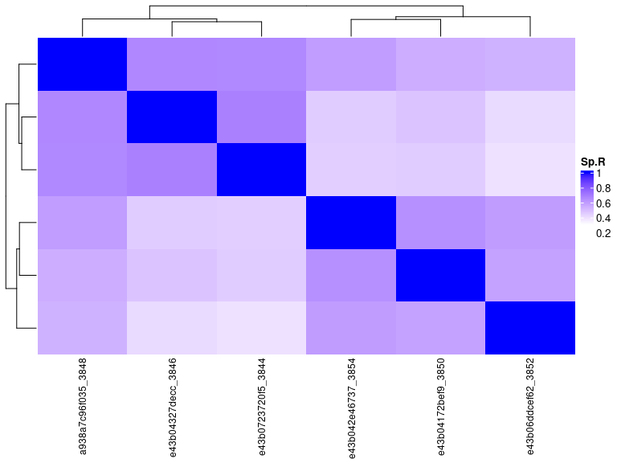

```r
library(ggplot2)
plotBambu(se, type = "heatmap")
```

Additionally, we can also visualise the correlation with a 2-dimmensional PCA plot.

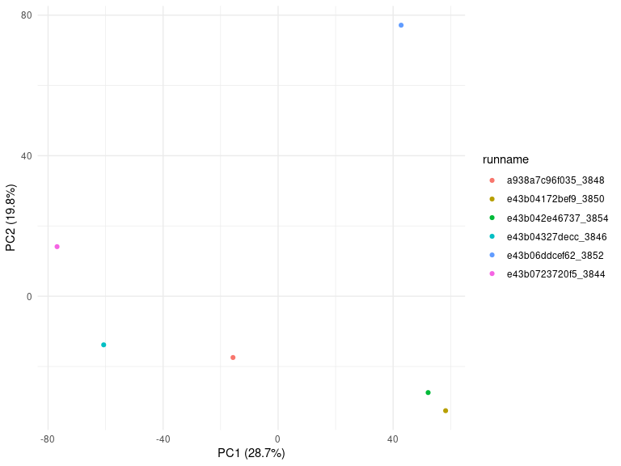

```r
plotBambu(se, type = "pca")
```

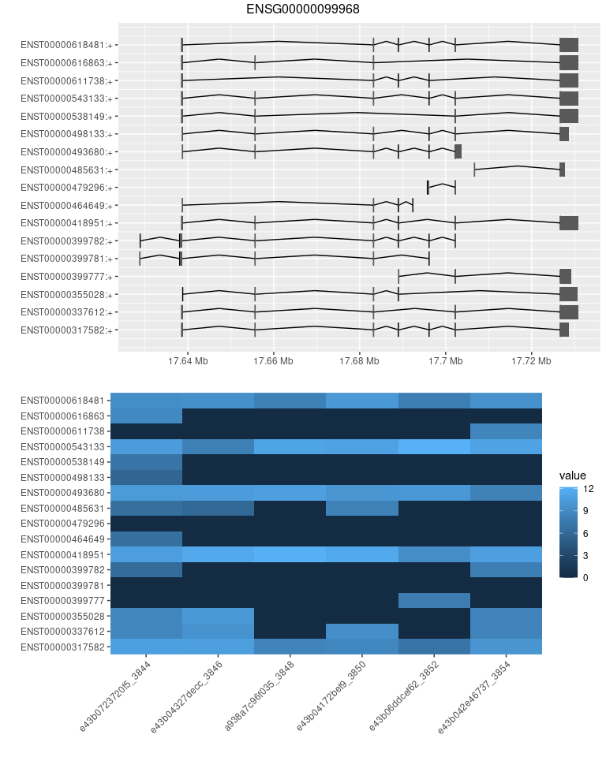

```
##> [[1]]
##> TableGrob (3 x 1) "arrange": 3 grobs
##>   z     cells    name                grob
##> 1 1 (2-2,1-1) arrange      gtable[layout]
##> 2 2 (3-3,1-1) arrange      gtable[layout]
##> 3 3 (1-1,1-1) arrange text[GRID.text.250]
```

```r
plotBambu(se, type = "annotation", gene_id = "ENSG00000099968")
```

### Obtain gene expression estimates from transcript expression

{#gene-expression} Gene expression can be calculated from the transcript expression estimates returned by *bambu* using the function. Looking at the output, we can see there are novel genes identified as well

```r
seGene <- transcriptToGeneExpression(se)
seGene
##> class: RangedSummarizedExperiment
##> dim: 574 6
##> metadata(0):
##> assays(2): counts CPM
##> rownames(574): ENSG00000015475 ENSG00000040608 ... gene.43 gene.45
##> rowData names(2): GENEID newGeneClass
##> colnames(6): e43b0723720f5_3844 e43b04327decc_3846 ...
##>   e43b06ddcef62_3852 e43b042e46737_3854
##> colData names(4): name d_rate nGeneFordRate condition
```

We can again use the function to visualise the gene expression data across the 6 samples with a heatmap or PCA plot. As expected, samples from the same cell line showed higher correlation than across the cell lines.

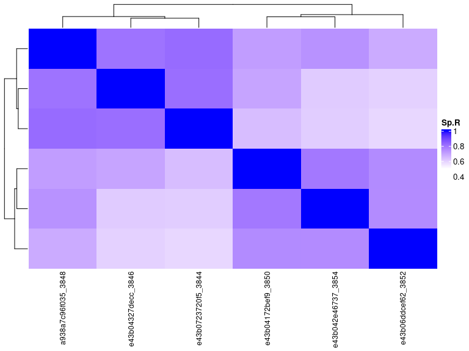

```r
colData(seGene)$groupVar <- SGNexSamples$cellLine
plotBambu(seGene, type = "heatmap")
```

### Save data (gtf/text)

*bambu* includes a function to write the extended annotations, the transcript and the gene expression estimates that include any newly discovered genes and transcripts to text files.

```r
save.dir <- tempdir()
writeBambuOutput(se, path = save.dir, prefix = "NanoporeRNASeq_")
```

*bambu* also includes a function that only exports the extended annotations to gtf file:

```r
save.file <- tempfile(fileext = ".gtf")
writeToGTF(rowRanges(se), file = save.file)
```

## Identifying differentially expressed genes

One of the most common tasks when analysing RNA-Seq data is the analysis of differential gene expression across a condition of intertest. Here we use *DESeq2* to find the differentially expressed genes between MCF7 and K562 cell lines. Similar to using results from *Salmon*, estimates from *bambu* will first be rounded.

```r
library(DESeq2)
dds <- DESeqDataSetFromMatrix(round(assays(seGene)$counts), colData = colData(se),
    design = ~condition)
dds.deseq <- DESeq(dds)
deGeneRes <- DESeq2::results(dds.deseq, independentFiltering = FALSE)
head(deGeneRes[order(deGeneRes$padj), ])
##> log2 fold change (MLE): condition MCF7 vs K562
##> Wald test p-value: condition MCF7 vs K562
##> DataFrame with 6 rows and 6 columns
##>                  baseMean log2FoldChange     lfcSE      stat
##>                 <numeric>      <numeric> <numeric> <numeric>
##> ENSG00000185686  500.6470       -7.15159  0.500364 -14.29278
##> ENSG00000283633   95.7518       -9.10519  1.246517  -7.30451
##> ENSG00000197077   26.9189        9.17563  1.320390   6.94918
##> ENSG00000240972 2443.3934        2.47082  0.357369   6.91392
##> ENSG00000099977  235.8601        1.92963  0.306609   6.29347
##> ENSG00000169635   43.5245       -3.36897  0.569649  -5.91411
##>                                                                pvalue
##>                                                             <numeric>
##> ENSG00000185686 0.000000000000000000000000000000000000000000000242728
##> ENSG00000283633 0.000000000000278275679947602694397391918138592006762
##> ENSG00000197077 0.000000000003674139901044544811771829869715655608568
##> ENSG00000240972 0.000000000004714473225560826484330951067763324359265
##> ENSG00000099977 0.000000000310450546572332925146307722118438170155752
##> ENSG00000169635 0.000000003336692881462437529443458496432317605950857
##>                                                                padj
##>                                                           <numeric>
##> ENSG00000185686 0.0000000000000000000000000000000000000000000631093
##> ENSG00000283633 0.0000000000361758383931883483531512278605162501177
##> ENSG00000197077 0.0000000003064407596614537449075252608477826568589
##> ENSG00000240972 0.0000000003064407596614537449075252608477826568589
##> ENSG00000099977 0.0000000161434284217613106600419295823603538231339
##> ENSG00000169635 0.0000001445900248633722995599947686029551618958067
```

A quick summary of differentially expressed genes

```r
summary(deGeneRes)
##>
##> out of 260 with nonzero total read count
##> adjusted p-value < 0.1
##> LFC > 0 (up)       : 19, 7.3%
##> LFC < 0 (down)     : 22, 8.5%
##> outliers [1]       : 0, 0%
##> low counts [2]     : 0, 0%
##> (mean count < 0)
##> [1] see 'cooksCutoff' argument of ?results
##> [2] see 'independentFiltering' argument of ?results
```

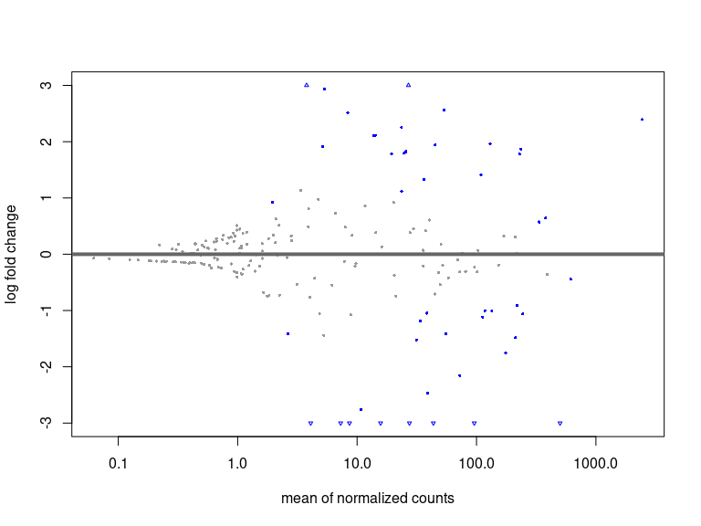

```r
library(apeglm)
resLFC <- lfcShrink(dds.deseq, coef = "condition_MCF7_vs_K562", type = "apeglm")
plotMA(resLFC, ylim = c(-3, 3))
```

## Identifying differential transcript usage

We used *DEXSeq* to detect alternative used isoforms.

```r
library(DEXSeq)
dxd <- DEXSeqDataSet(countData = round(assays(se)$counts), sampleData = as.data.frame(colData(se)),
    design = ~sample + exon + condition:exon, featureID = rowData(se)$TXNAME, groupID = rowData(se)$GENEID)
dxr <- DEXSeq(dxd)
head(dxr)
##>
##> LRT p-value: full vs reduced
##>
##> DataFrame with 6 rows and 12 columns
##>                              groupID   featureID exonBaseMean dispersion
##>                          <character> <character>    <numeric>  <numeric>
##> gene.30:tx.1                 gene.30        tx.1     9.059656         NA
##> gene.35:tx.2                 gene.35        tx.2     1.046280         NA
##> gene.12:tx.3                 gene.12        tx.3     1.054917         NA
##> ENSG00000184702:tx.4 ENSG00000184702        tx.4    32.603977   0.904929
##> ENSG00000183506:tx.5 ENSG00000183506        tx.5    14.804874   1.399618
##> gene.45:tx.6                 gene.45        tx.6     0.767463         NA
##>                           stat    pvalue      padj      K562      MCF7
##>                      <numeric> <numeric> <numeric> <numeric> <numeric>
##> gene.30:tx.1                NA        NA        NA        NA        NA
##> gene.35:tx.2                NA        NA        NA        NA        NA
##> gene.12:tx.3                NA        NA        NA        NA        NA
##> ENSG00000184702:tx.4   1.86587  0.171949  0.591465   1.31079   1.64896
##> ENSG00000183506:tx.5   1.32103  0.250408  0.631580   1.06310   1.20895
##> gene.45:tx.6                NA        NA        NA        NA        NA
##>                      log2fold_MCF7_K562   genomicData     countData
##>                               <numeric> <GRangesList>      <matrix>
##> gene.30:tx.1                         NA                 36:48:5:...
##> gene.35:tx.2                         NA                   9:5:0:...
##> gene.12:tx.3                         NA                   8:3:2:...
##> ENSG00000184702:tx.4            1.16294               24:132:88:...
##> ENSG00000183506:tx.5            0.52293                43:61:24:...
##> gene.45:tx.6                         NA                   5:5:0:...
```

We can visualize the MA-plot

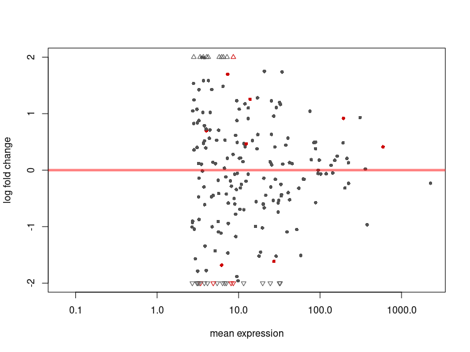

```r
plotMA(dxr, cex = 0.8)
```

# Running bambu with large number of samples

```r
se <- bambu(reads = bamFiles, rcOutDir = "./bambu/", annotations = annotaiton, genome = genomeSequence)
```

# Bambu parameters

## Advanced Options

- Keep novel transcripts with min 5 read count in at least 1 sample:

```r
bambu(reads, annotations, genome, opt.discovery = list(min.readCount = 5))
```

- Keep novel transcripts with min 5 samples having at least 2 counts:

```r
bambu(reads, annotations, genome, opt.discovery = list(min.sampleNumber = 5))
```

- Filter out transcripts with relative abundance within gene lower than 10%:

```r
bambu(reads, annotations, genome, opt.discovery = list(min.readFractionByGene = 0.1))
```

### Quantification without bias correction

The default estimation automatically does bias correction for expression estimates. However, you can choose to perform the quantification without bias correction.

```r
bambu(reads, annotations, genome, opt.em = list(bias = FALSE))
```

### Parallel computation

bambu allows parallel computation.

```r
bambu(reads, annotations, genome, ncore = 8)
```

See *[our page](https://goekelab.github.io/bambu/)* for details to customize other conditions.

# Getting help

Questions and issues can be raised at the Bioconductor support site (once bambu is available through bioconductor): https://support.bioconductor.org. Please tag your your posts with bambu.

Alternatively, issues can be raised at the bambu Github repository:https://github.com/GoekeLab/bambu.

# Citing bambu

A manuscript describing bambu is currently in preparation. If you use bambu for your research, please cite using the following doi: 10.5281/zenodo.3900025.

# Session Information

```r
sessionInfo()
##> R version 4.2.0 RC (2022-04-19 r82224)
##> Platform: x86_64-pc-linux-gnu (64-bit)
##> Running under: Ubuntu 20.04.4 LTS
##>
##> Matrix products: default
##> BLAS:   /home/biocbuild/bbs-3.15-bioc/R/lib/libRblas.so
##> LAPACK: /home/biocbuild/bbs-3.15-bioc/R/lib/libRlapack.so
##>
##> locale:
##>  [1] LC_CTYPE=en_US.UTF-8       LC_NUMERIC=C
##>  [3] LC_TIME=en_GB              LC_COLLATE=C
##>  [5] LC_MONETARY=en_US.UTF-8    LC_MESSAGES=en_US.UTF-8
##>  [7] LC_PAPER=en_US.UTF-8       LC_NAME=C
##>  [9] LC_ADDRESS=C               LC_TELEPHONE=C
##> [11] LC_MEASUREMENT=en_US.UTF-8 LC_IDENTIFICATION=C
##>
##> attached base packages:
##> [1] stats4    stats     graphics  grDevices utils     datasets  methods
##> [8] base
##>
##> other attached packages:
##>  [1] DEXSeq_1.42.0
##>  [2] RColorBrewer_1.1-3
##>  [3] AnnotationDbi_1.58.0
##>  [4] BiocParallel_1.30.0
##>  [5] apeglm_1.18.0
##>  [6] DESeq2_1.36.0
##>  [7] ggplot2_3.3.5
##>  [8] BSgenome.Hsapiens.NCBI.GRCh38_1.3.1000
##>  [9] Rsamtools_2.12.0
##> [10] NanoporeRNASeq_1.5.1
##> [11] ExperimentHub_2.4.0
##> [12] AnnotationHub_3.4.0
##> [13] BiocFileCache_2.4.0
##> [14] dbplyr_2.1.1
##> [15] bambu_2.2.0
##> [16] BSgenome_1.64.0
##> [17] rtracklayer_1.56.0
##> [18] Biostrings_2.64.0
##> [19] XVector_0.36.0
##> [20] SummarizedExperiment_1.26.0
##> [21] Biobase_2.56.0
##> [22] GenomicRanges_1.48.0
##> [23] GenomeInfoDb_1.32.0
##> [24] IRanges_2.30.0
##> [25] S4Vectors_0.34.0
##> [26] BiocGenerics_0.42.0
##> [27] MatrixGenerics_1.8.0
##> [28] matrixStats_0.62.0
##>
##> loaded via a namespace (and not attached):
##>   [1] utf8_1.2.2                    tidyselect_1.1.2
##>   [3] RSQLite_2.2.12                htmlwidgets_1.5.4
##>   [5] grid_4.2.0                    munsell_0.5.0
##>   [7] codetools_0.2-18              statmod_1.4.36
##>   [9] xgboost_1.6.0.1               withr_2.5.0
##>  [11] colorspace_2.0-3              filelock_1.0.2
##>  [13] OrganismDbi_1.38.0            highr_0.9
##>  [15] knitr_1.38                    rstudioapi_0.13
##>  [17] labeling_0.4.2                bbmle_1.0.24
##>  [19] GenomeInfoDbData_1.2.8        hwriter_1.3.2.1
##>  [21] bit64_4.0.5                   farver_2.1.0
##>  [23] coda_0.19-4                   vctrs_0.4.1
##>  [25] generics_0.1.2                xfun_0.30
##>  [27] biovizBase_1.44.0             R6_2.5.1
##>  [29] doParallel_1.0.17             clue_0.3-60
##>  [31] locfit_1.5-9.5                AnnotationFilter_1.20.0
##>  [33] bitops_1.0-7                  cachem_1.0.6
##>  [35] reshape_0.8.9                 DelayedArray_0.22.0
##>  [37] assertthat_0.2.1              promises_1.2.0.1
##>  [39] BiocIO_1.6.0                  scales_1.2.0
##>  [41] nnet_7.3-17                   gtable_0.3.0
##>  [43] Cairo_1.5-15                  ggbio_1.44.0
##>  [45] ensembldb_2.20.0              rlang_1.0.2
##>  [47] genefilter_1.78.0             GlobalOptions_0.1.2
##>  [49] splines_4.2.0                 lazyeval_0.2.2
##>  [51] dichromat_2.0-0               checkmate_2.1.0
##>  [53] BiocManager_1.30.17           yaml_2.3.5
##>  [55] reshape2_1.4.4                GenomicFeatures_1.48.0
##>  [57] backports_1.4.1               httpuv_1.6.5
##>  [59] Hmisc_4.7-0                   RBGL_1.72.0
##>  [61] tools_4.2.0                   ellipsis_0.3.2
##>  [63] jquerylib_0.1.4               Rcpp_1.0.8.3
##>  [65] plyr_1.8.7                    base64enc_0.1-3
##>  [67] progress_1.2.2                zlibbioc_1.42.0
##>  [69] purrr_0.3.4                   RCurl_1.98-1.6
##>  [71] prettyunits_1.1.1             rpart_4.1.16
##>  [73] GetoptLong_1.0.5              cluster_2.1.3
##>  [75] magrittr_2.0.3                data.table_1.14.2
##>  [77] magick_2.7.3                  circlize_0.4.14
##>  [79] mvtnorm_1.1-3                 ProtGenerics_1.28.0
##>  [81] hms_1.1.1                     mime_0.12
##>  [83] evaluate_0.15                 xtable_1.8-4
##>  [85] XML_3.99-0.9                  emdbook_1.3.12
##>  [87] jpeg_0.1-9                    gridExtra_2.3
##>  [89] shape_1.4.6                   bdsmatrix_1.3-4
##>  [91] compiler_4.2.0                biomaRt_2.52.0
##>  [93] tibble_3.1.6                  crayon_1.5.1
##>  [95] htmltools_0.5.2               later_1.3.0
##>  [97] Formula_1.2-4                 tidyr_1.2.0
##>  [99] geneplotter_1.74.0            DBI_1.1.2
##> [101] formatR_1.12                  ComplexHeatmap_2.12.0
##> [103] MASS_7.3-57                   rappdirs_0.3.3
##> [105] Matrix_1.4-1                  cli_3.3.0
##> [107] parallel_4.2.0                pkgconfig_2.0.3
##> [109] GenomicAlignments_1.32.0      numDeriv_2016.8-1.1
##> [111] foreign_0.8-82                xml2_1.3.3
##> [113] foreach_1.5.2                 annotate_1.74.0
##> [115] bslib_0.3.1                   stringr_1.4.0
##> [117] VariantAnnotation_1.42.0      digest_0.6.29
##> [119] graph_1.74.0                  rmarkdown_2.14
##> [121] htmlTable_2.4.0               restfulr_0.0.13
##> [123] curl_4.3.2                    shiny_1.7.1
##> [125] rjson_0.2.21                  lifecycle_1.0.1
##> [127] jsonlite_1.8.0                fansi_1.0.3
##> [129] pillar_1.7.0                  lattice_0.20-45
##> [131] GGally_2.1.2                  KEGGREST_1.36.0
##> [133] fastmap_1.1.0                 httr_1.4.2
##> [135] survival_3.3-1                interactiveDisplayBase_1.34.0
##> [137] glue_1.6.2                    png_0.1-7
##> [139] iterators_1.0.14              BiocVersion_3.15.2
##> [141] bit_4.0.4                     stringi_1.7.6
##> [143] sass_0.4.1                    blob_1.2.3
##> [145] latticeExtra_0.6-29           memoise_2.0.1
##> [147] dplyr_1.0.8
```